# 06 - Splines and Smoothing

Biostatistics 735 — Machine Learning in Public Health

Author

Alexander McLain

Published

September 8, 2026

# 1 Overview

Splines and GAMs show up in this course in two practical situations, and we will take each in turn:

1. **Checking the functional form of a predictor.** You already have a regression model with ordinary scalar predictors (age, BMI, blood pressure…). The question is whether each predictor should enter linearly, or whether the relationship is curved enough that a linear term is misspecifying the model.
2. **A predictor that is genuinely a curve, not a number.** Sometimes a single observation’s “predictor” is an entire function — a growth curve, a biomarker trajectory, an imaging tract profile — measured at many points. This is not a functional-form question; the covariate itself is functional.

Both situations are handled with `mgcv::gam()` and its `s()` smooth-term syntax. We will not construct spline basis matrices by hand — `gam()` does that internally, chooses the smoothing parameter for you (via REML/ML), and gives you confidence bands and significance tests directly.

# 2 Checking Functional Form in a Linear Model

We use the body fat data, predicting `bodyfat` from `abdomen`, `height`, and `age`.

```r
bf_df <- read_csv("bodyfat2.csv") |>
  select(bodyfat, abdomen, height, age)

head(bf_df)
```

```
# A tibble: 6 × 4
  bodyfat abdomen height   age
    <dbl>   <dbl>  <dbl> <dbl>
1    12.3    85.2   67.8    23
2     6.1    83     72.2    22
3    25.3    87.9   66.2    22
4    10.4    86.4   72.2    26
5    28.7   100     71.2    24
6    20.9    94.4   74.8    24
```

This is the standard exploratory workflow for deciding whether a predictor needs anything beyond a linear term: start with marginal plots, move to partial-residual plots once other covariates are in the model, then let a GAM tell you directly whether curvature is actually needed.

## 2.1 Step 1: Marginal Scatterplots

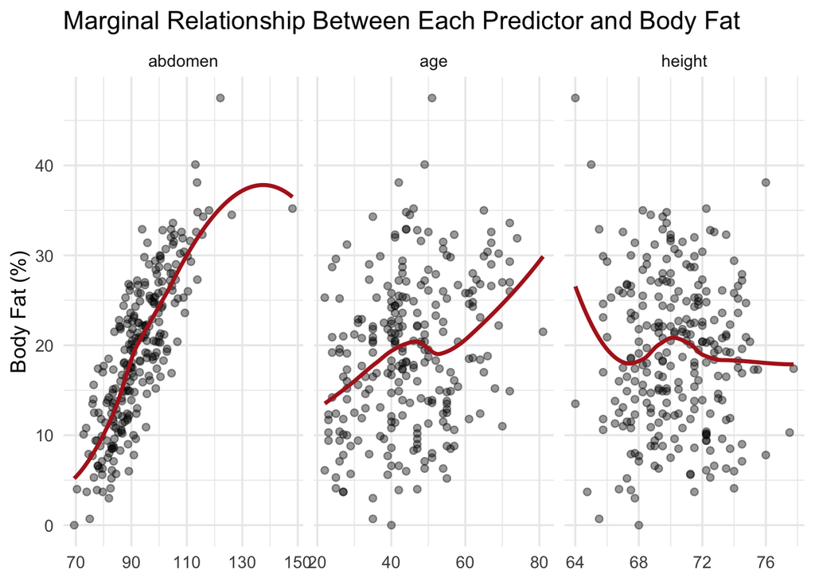

```r
bf_df |>
  pivot_longer(c(abdomen, height, age), names_to = "predictor", values_to = "x") |>
  ggplot(aes(x, bodyfat)) +
  geom_point(alpha = 0.4) +
  geom_smooth(se = FALSE, color = "firebrick") +
  facet_wrap(~ predictor, scales = "free_x") +
  theme_minimal(base_size = 13) +
  labs(x = NULL, y = "Body Fat (%)",
       title = "Marginal Relationship Between Each Predictor and Body Fat")
```

**Important**

A scatterplot like this shows the **marginal** relationship between one predictor and the outcome — it ignores every other variable in the model. Curvature (or the lack of it) here is a starting point, not a final answer: once `abdomen`, `height`, and `age` are all in the same model together, the apparent shape for any one of them can change.

## 2.2 Step 2: Partial-Residual Plots (`car::crPlots`)

Fit the ordinary linear model first, with every predictor entered linearly:

```r
lm_fit <- lm(bodyfat ~ abdomen + height + age, data = bf_df)
summary(lm_fit)
```

```
Call:
lm(formula = bodyfat ~ abdomen + height + age, data = bf_df)

Residuals:
     Min       1Q   Median       3Q      Max
-18.8092  -3.2826  -0.0031   3.3217  10.3120

Coefficients:
            Estimate Std. Error t value Pr(>|t|)
(Intercept) -4.27937    8.44847  -0.507    0.613
abdomen      0.64574    0.02883  22.400  < 2e-16 ***
height      -0.54157    0.11956  -4.529 9.19e-06 ***
age          0.03874    0.02498   1.551    0.122
---
Signif. codes:  0 '***' 0.001 '**' 0.01 '*' 0.05 '.' 0.1 ' ' 1

Residual standard error: 4.626 on 248 degrees of freedom
Multiple R-squared:  0.6981,    Adjusted R-squared:  0.6944
F-statistic: 191.1 on 3 and 248 DF,  p-value: < 2.2e-16
```

`car::crPlots()` gives **component-plus-residual (partial-residual) plots** — for each predictor, the relationship with the outcome *after adjusting for* the other predictors in the model. This is the same tool we used earlier in the course for checking linearity assumptions.

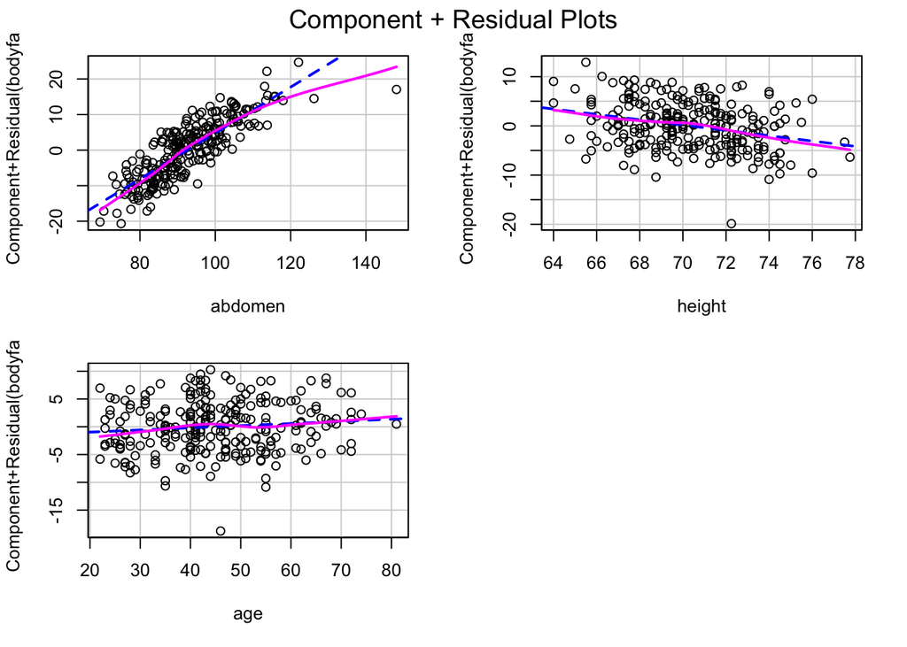

```r
crPlots(lm_fit)
```

Each panel shows a dashed line (the fitted linear term) against a solid loess line (a smooth fit to the partial residuals). When the two lines track closely, a linear term is reasonable. When the loess line bows away from the dashed line, that predictor’s relationship with the outcome is probably not linear — `abdomen` is the one to watch here.

## 2.3 Step 3: Let `gam()` Decide

Rather than eyeballing the crPlots, fit a GAM with a smooth term for each predictor and let `mgcv` estimate how much curvature the data actually support.

```r
gam_fit <- gam(bodyfat ~ s(abdomen) + s(height) + s(age),
               data = bf_df, method = "REML")
summary(gam_fit)
```

```
Family: gaussian
Link function: identity

Formula:
bodyfat ~ s(abdomen) + s(height) + s(age)

Parametric coefficients:
            Estimate Std. Error t value Pr(>|t|)
(Intercept)  19.1508     0.2784   68.79   <2e-16 ***
---
Signif. codes:  0 '***' 0.001 '**' 0.01 '*' 0.05 '.' 0.1 ' ' 1

Approximate significance of smooth terms:
             edf Ref.df      F  p-value
s(abdomen) 3.688  4.611 124.13  < 2e-16 ***
s(height)  1.000  1.001  28.35 3.15e-07 ***
s(age)     1.001  1.001   1.05    0.306
---
Signif. codes:  0 '***' 0.001 '**' 0.01 '*' 0.05 '.' 0.1 ' ' 1

R-sq.(adj) =  0.721   Deviance explained = 72.7%
-REML = 734.05  Scale est. = 19.531    n = 252
```

Two things to read from the summary table:

- **`edf`** (effective degrees of freedom): `edf ≈ 1` means the smooth term has effectively collapsed to a straight line — no evidence of curvature. `edf` noticeably above 1 means the model is using real curvature to fit that predictor.
- **The p-value** for each smooth term tests whether that term contributes anything beyond a flat/no effect — not specifically whether it’s nonlinear.

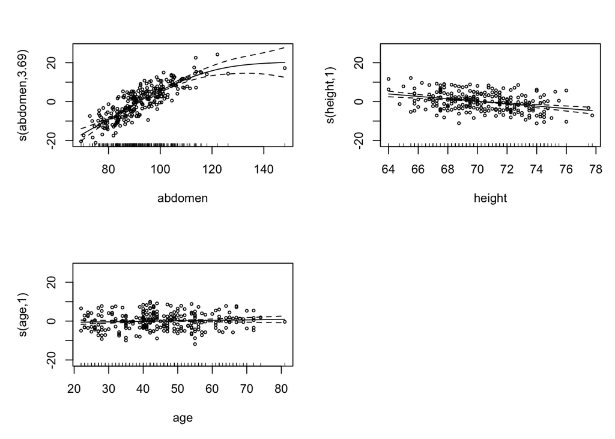

```r
plot(gam_fit, pages = 1, shade = TRUE, residuals = TRUE, pch = 1, cex = 0.5)
```

These plots are the GAM analogue of the crPlots above: partial effect of each predictor (adjusted for the others) with a confidence band and the partial residuals overlaid.

## 2.4 Step 4: Linear vs. Smooth — a Direct Comparison

To formally check whether the smooth terms are earning their keep, compare a fully linear model to the GAM (both fit with `method = "ML"` so the comparison is valid):

```r
lm_ml   <- gam(bodyfat ~ abdomen + height + age, data = bf_df, method = "ML")
gam_ml  <- gam(bodyfat ~ s(abdomen) + s(height) + s(age), data = bf_df, method = "ML")

anova(lm_ml, gam_ml, test = "F")
```

```
Analysis of Deviance Table

Model 1: bodyfat ~ abdomen + height + age
Model 2: bodyfat ~ s(abdomen) + s(height) + s(age)
  Resid. Df Resid. Dev    Df Deviance      F    Pr(>F)
1    248.00     5307.5
2    244.19     4800.5 3.809   506.98 6.8087 4.602e-05 ***
---
Signif. codes:  0 '***' 0.001 '**' 0.01 '*' 0.05 '.' 0.1 ' ' 1
```

**Tip**

**Practical takeaway.** If `edf` is close to 1 for a predictor and the linear-vs-smooth comparison doesn’t favor the GAM, drop the smooth and use the plain linear term — it’s simpler and just as good. Reserve `s()` for the predictors that actually show curvature, like `abdomen` here. You do not need to smooth every predictor just because you smoothed one.

# 3 A Genuinely Functional Covariate

The example above still has ordinary, scalar predictors — the only question was the *shape* of their effect. Here the predictor itself is a curve: at each observation, we don’t observe a single abdomen measurement, we observe an entire profile measured across many positions.

We’ll use a Diffusion Tensor Imaging (DTI) dataset from the `refund` package: diffusion tensor imaging data from a study of multiple sclerosis. For each subject/visit, we have **fractional anisotropy (FA),** FA is a number from 0 to 1 that measures how much water molecules move in a specific direction versus all directions.

- *High FA (closer to 1):* Shows healthy, dense, and well-organized white matter tracks.
- *Low FA (closer to 0):* Shows damaged, less dense, or disorganized fibers, often caused by aging, injury, or diseases like multiple sclerosis and depression.

Here, we have FA measured at 93 positions along the corpus callosum — a white-matter tract profile — along with a cognitive processing score, `pasat` (Paced Auditory Serial Addition Test).

```r
data(DTI)
str(DTI)
```

```
'data.frame':   382 obs. of  9 variables:
 $ ID        : num  1001 1002 1003 1004 1005 ...
 $ visit     : int  1 1 1 1 1 1 1 1 1 1 ...
 $ visit.time: int  0 0 0 0 0 0 0 0 0 0 ...
 $ Nscans    : int  1 1 1 1 1 1 1 1 1 1 ...
 $ case      : num  0 0 0 0 0 0 0 0 0 0 ...
 $ sex       : Factor w/ 2 levels "male","female": 2 2 1 1 1 1 1 1 1 1 ...
 $ pasat     : int  NA NA NA NA NA NA NA NA NA NA ...
 $ cca       : num [1:382, 1:93] 0.491 0.472 0.502 0.402 0.402 ...
  ..- attr(*, "dimnames")=List of 2
  .. ..$ : chr [1:382] "1001_1" "1002_1" "1003_1" "1004_1" ...
  .. ..$ : chr [1:93] "cca_1" "cca_2" "cca_3" "cca_4" ...
 $ rcst      : num [1:382, 1:55] 0.257 NaN NaN 0.508 NaN ...
  ..- attr(*, "dimnames")=List of 2
  .. ..$ : chr [1:382] "1001_1" "1002_1" "1003_1" "1004_1" ...
  .. ..$ : chr [1:55] "rcst_1" "rcst_2" "rcst_3" "rcst_4" ...
```

`DTI$cca` is a matrix: one row per observation, one column per tract position. That whole row — not any single number from it — is the predictor.

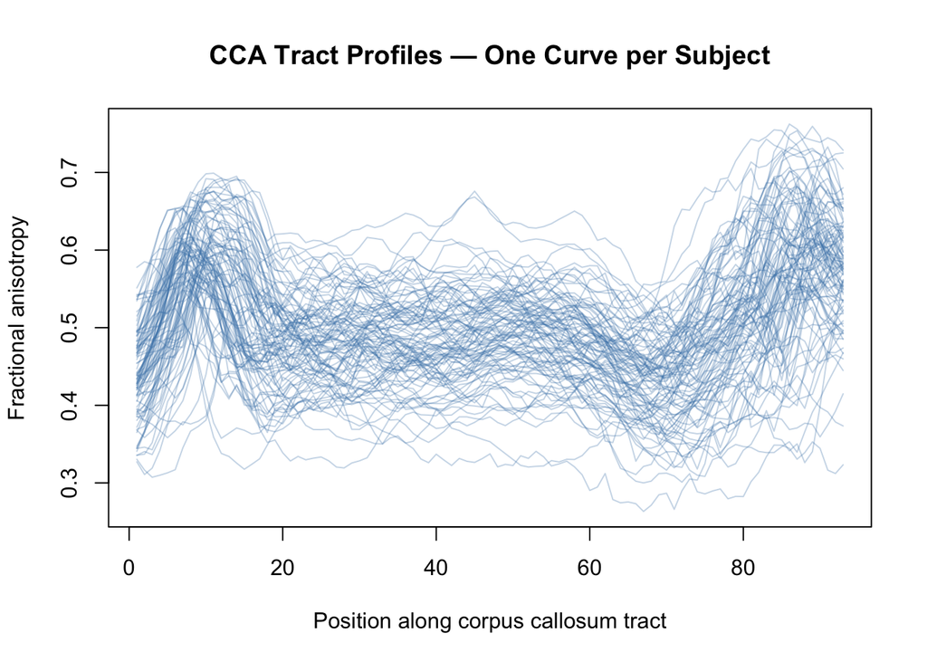

```r
dti0 <- DTI |>
  filter(visit == 1, !is.na(pasat), rowSums(is.na(cca)) == 0)

matplot(t(dti0$cca), type = "l", lty = 1,
        col = adjustcolor("steelblue", alpha.f = 0.3),
        xlab = "Position along corpus callosum tract",
        ylab = "Fractional anisotropy",
        main = "CCA Tract Profiles — One Curve per Subject")
```

## 3.1 Scalar-on-Function Regression

We want to relate this curve to a scalar outcome (`pasat`). This is **scalar-on-function regression**, fit here with `refund::pfr()`, which extends the same `gam()` machinery to functional predictors via the `lf()` (“linear functional”) term.

```r
fit_func <- pfr(pasat ~ lf(cca), data = dti0)
summary(fit_func)
```

```
Family: gaussian
Link function: identity

Formula:
pasat ~ s(x = cca.tmat, by = L.cca)

Parametric coefficients:
            Estimate Std. Error t value Pr(>|t|)
(Intercept)   0.6659    12.8733   0.052    0.959

Approximate significance of smooth terms:
                    edf Ref.df     F p-value
s(cca.tmat):L.cca 2.001  2.003 5.981 0.00355 **
---
Signif. codes:  0 '***' 0.001 '**' 0.01 '*' 0.05 '.' 0.1 ' ' 1

R-sq.(adj) =  0.0925   Deviance explained = 11.1%
-REML = 377.62  Scale est. = 153.32    n = 99
```

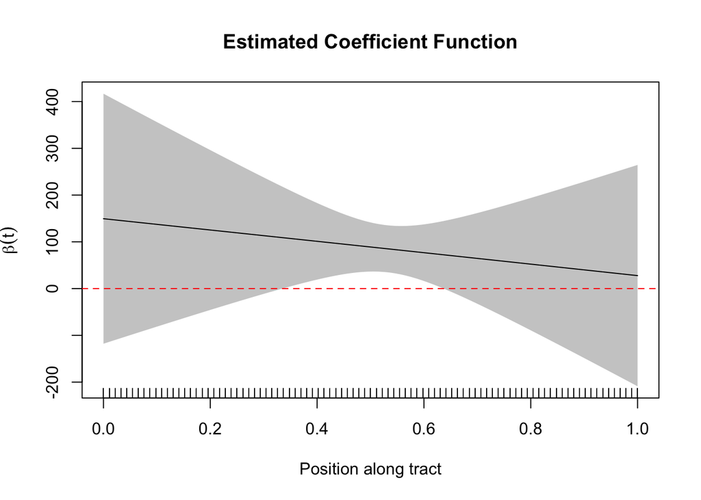

```r
plot(fit_func, shade = TRUE,
     xlab = "Position along tract",
     ylab = expression(beta(t)),
     main = "Estimated Coefficient Function")
abline(h = 0, col = "red", lty = 2)
```

**Important**

The plot above is not a partial-effect curve for one predictor among several — it **is** the model’s entire estimated relationship between the tract profile and PASAT score. $\hat\beta(t)$ tells you, at each position $t$ along the tract, how strongly FA at that position is associated with the outcome. Where the confidence band excludes zero, that region of the tract is driving the association; where it doesn’t, that region isn’t contributing much.

This is a fundamentally different use of smoothing than Part 1: there, `s()` let us relax a linearity assumption on an otherwise ordinary predictor. Here, smoothness is doing double duty — it is how we represent a predictor that has no natural “linear” form to begin with, since there is no single number to enter into a regression.

**Note**

**Connection to the fused lasso.** The scalar-on-function regression above estimates $\hat\beta(t)$ by imposing a *smoothness* penalty (roughness of the coefficient curve, via the spline basis in `pfr()`). The fused lasso example from the penalized-regression material imposes a different kind of structure: instead of penalizing curvature, it penalizes $\sum_t |\beta_t - \beta_{t-1}|$, which encourages $\hat\beta(t)$ to be **piecewise constant** rather than smoothly varying.

Both are reasonable choices for a coefficient that’s indexed by an ordered position (here, location along the tract) rather than a arbitrary variable:

|  | Smoothing spline / GAM (`pfr`) | Fused lasso |
| --- | --- | --- |
| Assumes | $\beta(t)$ varies smoothly | $\beta(t)$ is flat within regions, with abrupt jumps between them |
| Penalty | On curvature (2nd derivative) | On adjacent differences ($\ell_1$) |
| Estimated shape | Smooth curve | Step function / plateaus |
| Best suited to | Gradual biological gradients | Genuine regime changes — e.g., a tract segment that matters and a neighboring segment that doesn’t |
| Coefficients can be exactly zero? | Only approximately, over a whole smooth region | Yes — the $\ell_1$ penalty can zero out entire flat segments |

For the DTI tract data, a smooth $\hat\beta(t)$ is the more natural assumption — anatomy doesn’t usually have sharp discontinuities. But if you believed only a specific, contiguous stretch of the tract mattered and the rest was truly irrelevant, a fused lasso on $\beta(t)$ (fusing adjacent positions, with an $\ell_1$ penalty that can drive whole segments to exactly zero) would recover that block structure more directly than a smoother would.

# 4 Using two-dimensional tensor regression

We’ll now look at an example which fits a multidimensional smoothing spline using *tensor product basis*. This action will be performed using the package we discussed in the last example.

```r
#Fit an ANOVA type tensor product interaction
b2 <- gam(bodyfat~ ti(abdomen) + ti(height) + ti(abdomen,height),
          data=bf_df,
          method = "REML")
summary(b2)
```

```
Family: gaussian
Link function: identity

Formula:
bodyfat ~ ti(abdomen) + ti(height) + ti(abdomen, height)

Parametric coefficients:
            Estimate Std. Error t value Pr(>|t|)
(Intercept)  19.2282     0.2821   68.17   <2e-16 ***
---
Signif. codes:  0 '***' 0.001 '**' 0.01 '*' 0.05 '.' 0.1 ' ' 1

Approximate significance of smooth terms:
                     edf Ref.df       F p-value
ti(abdomen)        3.012  3.479 181.162  <2e-16 ***
ti(height)         1.000  1.001  36.254  <2e-16 ***
ti(abdomen,height) 1.711  2.123   2.237   0.105
---
Signif. codes:  0 '***' 0.001 '**' 0.01 '*' 0.05 '.' 0.1 ' ' 1

R-sq.(adj) =  0.724   Deviance explained = 73.1%
-REML =  726.5  Scale est. = 19.301    n = 252
```

```r
#Estimated smoothing parameters for the model.
b2$sp
```

```
        ti(abdomen)          ti(height) ti(abdomen,height)1 ti(abdomen,height)2
       1.049624e+01        8.667933e+05        2.256283e+05        5.601665e-01
```

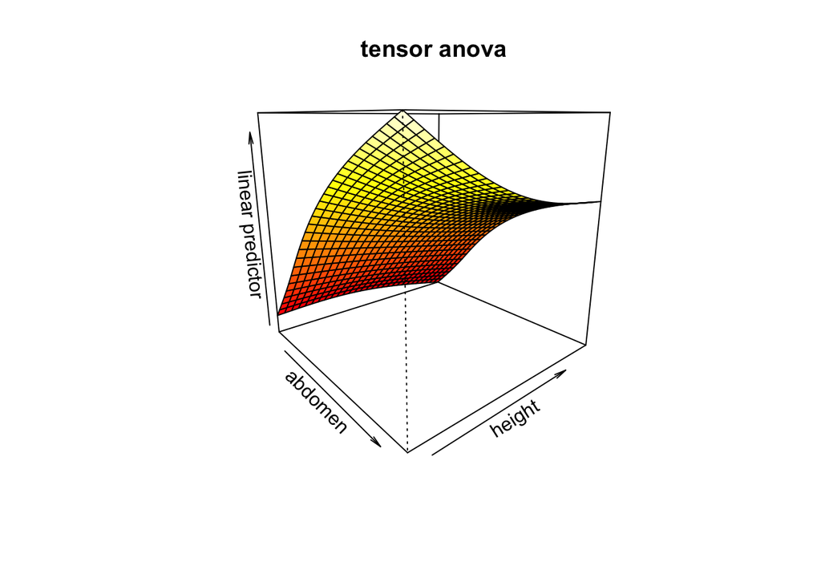

```r
#Plot the results.
vis.gam(b2, theta = 50);title("tensor anova")
```

# 5 Summary

- Use marginal scatterplots for a first look, but remember they ignore every other covariate in the model.
- `car::crPlots()` gives the partial-residual view once other predictors are accounted for — the tool we’ve already been using for linearity checks.
- `mgcv::gam()` with `s()` terms lets the data decide how much curvature is needed; check `edf` and compare linear vs. smooth models with `anova()` rather than smoothing every predictor by default.
- When the predictor itself is a curve (a tract profile, a growth trajectory, a biomarker measured densely over time), that’s a different problem — scalar-on-function regression (`refund::pfr()` with `lf()`) — not a functional-form question about a scalar predictor.
- There’s nothing written in the sky saying that the relationship between variables and outcomes will be simple. There can be two- and even three-way non-linear interactions.